# Final Project

Drew Insley

12/04/18

## Set Up

```r
rm(list = ls())
library(DataComputing)
library(rvest)
library(lubridate)
library(tidyr)
library(party)
```

## Introduction

**The data frame used for this project comes from data.cityofnewyork.us. It is titled “Fire Incident Dispatch Data”, and it contains data spanning from 2013-2017. I intend to demonstrate my skills with R by scraping, cleaning, and using this data for analysis.**

## Project

```r
# Get the Data
getwd()
```

```
[1] "/Users/drewinsley/InsleyFinalProject"
```

```r
setwd("~/Downloads")
FireIncidents <- read.csv("Fire_Incident_Dispatch_Data.csv")
```

```r
# Inspect the Data
str(FireIncidents)
```

```
'data.frame':   2755750 obs. of  29 variables:
 $ STARFIRE_INCIDENT_ID          : num  1.3e+15 1.3e+15 1.3e+15 1.3e+15 1.3e+15 ...
 $ INCIDENT_DATETIME             : Factor w/ 2724240 levels "01/01/2013 01:01:16 PM",..: 1337 1338 1339 1343 1345 1347 1349 1350 1351 1352 ...
 $ ALARM_BOX_BOROUGH             : Factor w/ 5 levels "BRONX","BROOKLYN",..: 1 3 4 4 4 2 3 4 1 1 ...
 $ ALARM_BOX_NUMBER              : int  2147 818 9656 4019 7412 1328 688 9604 2897 2275 ...
 $ ALARM_BOX_LOCATION            : Factor w/ 19762 levels "1 AV & LUIS M MARIN BLVD/116 ST",..: 17614 363 11928 19678 7067 1682 3543 4382 19244 8958 ...
 $ INCIDENT_BOROUGH              : Factor w/ 5 levels "BRONX","BROOKLYN",..: 1 3 4 4 4 2 3 4 1 1 ...
 $ ZIPCODE                       : int  10454 10036 11418 11385 11103 11232 10001 11418 10472 10451 ...
 $ POLICEPRECINCT                : int  40 18 102 104 114 72 14 102 43 40 ...
 $ CITYCOUNCILDISTRICT           : int  8 3 29 34 26 38 3 32 18 17 ...
 $ COMMUNITYDISTRICT             : int  201 104 409 405 401 307 105 409 209 201 ...
 $ COMMUNITYSCHOOLDISTRICT       : int  7 2 27 24 30 15 2 27 12 7 ...
 $ CONGRESSIONALDISTRICT         : int  15 10 5 7 14 10 12 7 15 15 ...
 $ ALARM_SOURCE_DESCRIPTION_TX   : Factor w/ 10 levels "BARS","DEFAULT RECORD",..: 3 8 3 8 9 8 9 9 9 7 ...
 $ ALARM_LEVEL_INDEX_DESCRIPTION : Factor w/ 10 levels "10-75 Signal (Request for all hands alarm)",..: 8 8 8 8 8 8 8 8 8 8 ...
 $ HIGHEST_ALARM_LEVEL           : Factor w/ 9 levels "All Hands Working",..: 5 5 5 5 5 5 5 5 5 5 ...
 $ INCIDENT_CLASSIFICATION       : Factor w/ 66 levels "Abandoned Derelict Vehicle Fire",..: 23 2 23 2 61 2 5 21 5 5 ...
 $ INCIDENT_CLASSIFICATION_GROUP : Factor w/ 6 levels "Medical Emergencies",..: 1 3 1 3 3 3 3 5 3 3 ...
 $ DISPATCH_RESPONSE_SECONDS_QY  : int  666 56 8 77 22 36 9 13 22 45 ...
 $ FIRST_ASSIGNMENT_DATETIME     : Factor w/ 2718154 levels "","01/01/2013 01:01:30 PM",..: 1372 1342 1341 1348 1346 1350 1351 1352 1354 1355 ...
 $ FIRST_ACTIVATION_DATETIME     : Factor w/ 2704501 levels "","01/01/2013 01:01:58 PM",..: 1365 1335 1333 1340 1339 1342 1343 1344 1346 1348 ...
 $ FIRST_ON_SCENE_DATETIME       : Factor w/ 2328086 levels "","01/01/2013 01:00:18 AM",..: 1215 1200 1189 1192 1195 1196 1211 1191 1203 1212 ...
 $ INCIDENT_CLOSE_DATETIME       : Factor w/ 2723001 levels "01/01/2013 01:00:00 AM",..: 1382 1407 1372 1395 1432 1377 1410 1366 1391 1373 ...
 $ VALID_DISPATCH_RSPNS_TIME_INDC: Factor w/ 1 level "N": 1 1 1 1 1 1 1 1 1 1 ...
 $ VALID_INCIDENT_RSPNS_TIME_INDC: Factor w/ 2 levels "N","Y": 1 2 2 2 2 2 2 2 2 2 ...
 $ INCIDENT_RESPONSE_SECONDS_QY  : int  843 506 218 278 316 310 555 136 385 527 ...
 $ INCIDENT_TRAVEL_TM_SECONDS_QY : int  177 450 210 201 294 274 546 123 363 482 ...
 $ ENGINES_ASSIGNED_QUANTITY     : int  1 1 1 3 2 1 0 3 0 0 ...
 $ LADDERS_ASSIGNED_QUANTITY     : int  0 1 0 2 1 1 2 2 1 1 ...
 $ OTHER_UNITS_ASSIGNED_QUANTITY : int  0 1 0 1 1 1 0 1 0 0 ...
```

```r
# Clean up the data
pattern <- ("[0-9]{2}[:][0-9]{2}[:][0-9]{2}")
FireIncidents <-
FireIncidents %>%
  select(INCIDENT_BOROUGH, INCIDENT_DATETIME, ENGINES_ASSIGNED_QUANTITY, INCIDENT_CLASSIFICATION_GROUP, ZIPCODE, LADDERS_ASSIGNED_QUANTITY) %>%
  rename(borough = INCIDENT_BOROUGH, date = INCIDENT_DATETIME, engines = ENGINES_ASSIGNED_QUANTITY, type = INCIDENT_CLASSIFICATION_GROUP, ladders = LADDERS_ASSIGNED_QUANTITY, zipcode = ZIPCODE) %>%
  mutate(date = gsub(pattern, " ", date)) %>%
  mutate(date = gsub("[AMP]{2}", " ", date)) %>%
  mutate(date = mdy(date))
FireIncidents %>%
  head(5)
```

|  | borough | date | engines | type | zipcode | ladders |
| --- | --- | --- | --- | --- | --- | --- |
| 1 | BRONX | 2013-01-01 | 1 | Medical Emergencies | 10454 | 0 |
| 2 | MANHATTAN | 2013-01-01 | 1 | NonMedical Emergencies | 10036 | 1 |
| 3 | QUEENS | 2013-01-01 | 1 | Medical Emergencies | 11418 | 0 |
| 4 | QUEENS | 2013-01-01 | 3 | NonMedical Emergencies | 11385 | 2 |
| 5 | QUEENS | 2013-01-01 | 2 | NonMedical Emergencies | 11103 | 1 |

**By changing the names of the variables and filtering out the unwanted ones, I have created a clean table. I will now make a chart of counts for incidents and ladders by borough, so that I can graph these data later.**

```r
# Make a chart of counts for ladders and incidents
FireCount <-
FireIncidents %>%
  group_by(borough) %>%
  summarise(incidents = n()) %>%
  arrange(desc(incidents))
FireLadders <-
FireIncidents %>%
  group_by(borough) %>%
  summarise(ladders = sum(ladders)) %>%
  arrange(desc(ladders))
FireJoin <-
  FireCount %>%
  inner_join(FireLadders)
```

**Before I check out this data, it is most important to look at specific locations where the most fires happen. I can do this by looking at fire incidents by ZipCode.**

```r
# Where do the most fires happen?
FireIncidents %>%
  select(borough, zipcode) %>%
  group_by(borough, zipcode) %>%
  summarise(count = n()) %>%
  arrange(desc(count)) %>%
  filter(zipcode != "NA") %>%
  head(5)
```

| borough | zipcode | count |
| --- | --- | --- |
| BRONX | 10456 | 42115 |
| MANHATTAN | 10029 | 40677 |
| BROOKLYN | 11212 | 38416 |
| BROOKLYN | 11207 | 37711 |
| MANHATTAN | 10002 | 35798 |

**ZipCodes 10456 and 10029 in the Bronx and Manhattan had the most incidents with 42115 and 40677 respectively. Now, I’ll look at which borough had the most as a whole.**

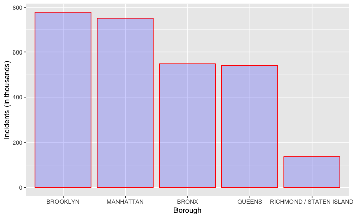

```r
# Which borough had the most number of fire incidents?
FireJoin %>%
  ggplot(aes(reorder(borough, desc(incidents)), incidents/1000)) +
  geom_bar(stat = "identity", fill = "blue", color = "red", alpha = .2) +
  xlab("Borough") +
  ylab("Incidents (in thousands)")
```

**The graph shows the descending order of fire incidents in the five boroughs of New York. Despite ZipCodes in the Bronx and Manhattan having the most fire incidents, the whole borough of Brooklyn had the most fire incidents with 777,725 occurances. Let’s see if the number of ladders deployed by borough will match with the amount of incidents by borough.**

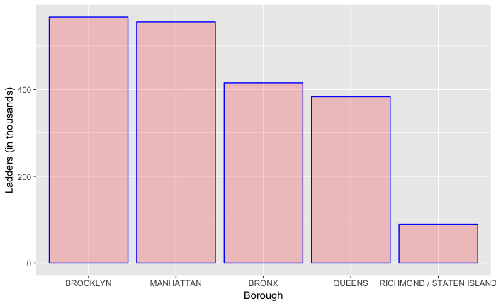

```r
# How many ladders were deployed?
FireJoin %>%
  ggplot(aes(reorder(borough, desc(ladders)), ladders/1000)) +
  geom_bar(stat = "identity", fill = "red", color = "blue", alpha = .2) +
  xlab("Borough") +
  ylab("Ladders (in thousands)")
```

**The number of ladders deployed does match to almost exactly three-quarters the amount of fire incidents by borough. In fact, the descending order of counts is the exact same. To further visualize this connection, we can plot ladders and incidents on a scatterplot.**

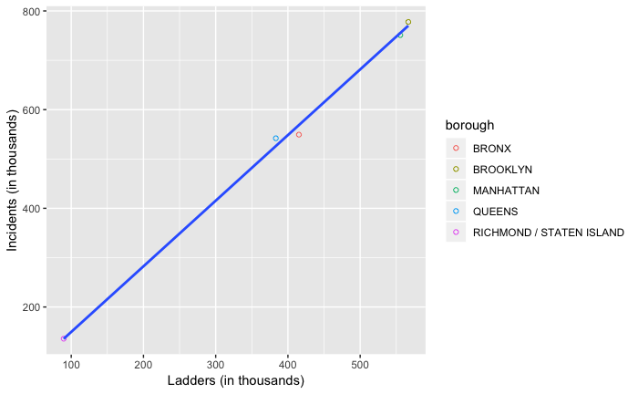

```r
# Plot ladders & incidents on a scatterplot
FireJoin %>%
  ggplot(aes(ladders/1000, incidents/1000)) +
  geom_point(shape = 1, aes(color = borough)) +
  geom_smooth(method = lm, se = FALSE) +
  xlab("Ladders (in thousands)") +
  ylab("Incidents (in thousands)")
```

**As the scatterplot shows, there is a clear linear relationship between the two variables and they are heavily correlated, as expected. Let’s take a look at which days these fires were most likely to occur.**

```r
# What days were these fires most likely to occur?
FireDays <-
FireIncidents %>%
  group_by(date) %>%
  summarise(count = n()) %>%
  mutate(rank = rank(desc(count))) %>%
  select(date, rank) %>%
  arrange(rank)
FireDays %>%
  head(5)
```

| date | rank |
| --- | --- |
| 2016-02-15 | 1 |
| 2016-02-16 | 2 |
| 2015-02-22 | 3 |
| 2015-02-16 | 4 |
| 2015-02-17 | 5 |

**Apparently people really like to start fires in February! In this case, the lower the rank, the higher the amount of fires. The 5 days with the most amounts of fires are all in the second month. However, we should look at which month had the most amount of medical emergencies, in order to determine the most dangerous month in terms of fire occurances.**

```r
# What month had the most medical emergencies?
pattern <- ("[0-7]{4}[-]")
FireTypes <-
FireIncidents %>%
  select(date, type) %>%
  mutate(date = gsub(pattern, " ", date)) %>%
  mutate(date = gsub(("[-][0-9]{2}"), " ", date)) %>%
  group_by(date, type) %>%
  summarise(emergencies = n()) %>%
  filter(type == 'Medical Emergencies') %>%
  arrange(desc(emergencies)) %>%
  select(date, emergencies)
FireTypes
```

| date | emergencies |
| --- | --- |
| 07 | 116668 |
| 08 | 115013 |
| 06 | 112743 |
| 10 | 110983 |
| 05 | 110263 |
| 09 | 109654 |
| 12 | 106208 |
| 11 | 101774 |
| 04 | 100009 |
| 01 | 98679 |

[output cut: 2 more lines]

**Oddly enough, even though the top five worst fire days were in February, the second month actually has the least amount of medical emergencies associated with those fires. In fact, the most medical emergencies come from July.**

## Conclusion

**The data show crucial elements of the location and severity of fire incidents in New York from 2013-2017. The most fires occured in ZipCodes 10456 and 10029 in the Bronx and Manhattan, but Brooklyn had the most fires as a whole, as well as the most fire ladders deployed. In addition, the top five worst days with respect to amount of fires were all in February, but the month with the most medical emergencies related to these fires was actually July. So if you are in New York in July, stay out of Brooklyn!**

## Thought Provoker

```r
# Show a ctree of Medical Emergencies based on Engines, and a linear model summary for Medical Emergencies based on Engines and Ladders
CTree <-
ctree(formula = type == "Medical Emergencies" ~ engines, data = FireIncidents)
Predictors <-
lm(formula = type == "Medical Emergencies" ~ engines + ladders, data = FireIncidents)
summary(Predictors)
```

```
Call:
lm(formula = type == "Medical Emergencies" ~ engines + ladders,
    data = FireIncidents)

Residuals:
   Min     1Q Median     3Q    Max
-7.703 -0.116  0.094  0.202 46.142

Coefficients:
              Estimate Std. Error t value Pr(>|t|)
(Intercept)  0.5878117  0.0003016  1948.7   <2e-16 ***
engines      0.2099862  0.0002483   845.6   <2e-16 ***
ladders     -0.5508780  0.0002853 -1930.7   <2e-16 ***
---
Signif. codes:  0 ‘***’ 0.001 ‘**’ 0.01 ‘*’ 0.05 ‘.’ 0.1 ‘ ’ 1

Residual standard error: 0.3141 on 2755747 degrees of freedom
Multiple R-squared:  0.6029,    Adjusted R-squared:  0.6029
F-statistic: 2.092e+06 on 2 and 2755747 DF,  p-value: < 2.2e-16
```

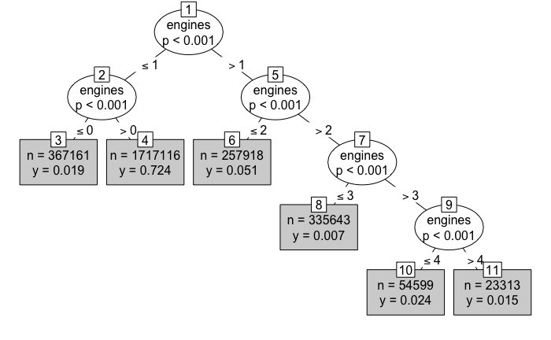

```r
plot(CTree, type = "simple")
```